# Predicting NFL Draft Position from Combine Performance

### Fall 2024 Data Science Project (CMSC320)

**Nakul, Samuel, Pratyaksh, Toby**

### Contributions

| Member | Sections | Summary |
| --- | --- | --- |
| Nakul | A, B, D, G | Picked the NFL Combine/Draft dataset, built the data cleaning + merge pipeline, implemented the regression models, and assembled the final tutorial notebook. |
| Samuel | B, C | Cleaned and typed the raw Kaggle CSVs, and ran the exploratory correlation, hypothesis-testing, and summary-statistics analysis. |
| Pratyaksh | D, E | Helped design the feature set for the ML models and ran training/evaluation experiments (train/test splits, metric comparisons) for the regression models. |
| Toby | F, H | Built the result visualizations, wrote the insights/conclusions section, and proofread the tutorial for clarity. |

## 1. Introduction

Every February, roughly 300 college football players attend the **NFL Scouting Combine**, where they run the 40-yard dash, bench press 225 lbs as many times as possible, do a standing vertical and broad jump, and run short-area agility drills (the shuttle and 3-cone). A few months later, NFL teams use that data — along with game film, interviews, and college production — to decide the order in which they draft players.

Sports media treats combine performance as a big deal ("draft stock riser/faller" stories are a cottage industry), but it's genuinely unclear how much these athletic tests actually predict where a player gets drafted, once you account for the fact that different positions are drafted on totally different criteria (a slow-footed offensive lineman and a burner wide receiver are not being compared to each other).

In this tutorial we use the [NFL Play Statistics Dataset (2004–Present)](https://www.kaggle.com/datasets/toddsteussie/nfl-play-statistics-dataset-2004-to-present) from Kaggle to answer:

Answering these questions matters for a few audiences: front offices trying to calibrate how much weight to put on workout numbers, draft analysts building models, and fans trying to know whether to trust "he ran a 4.3, he's going in round 1" narratives.

## 2. Data Curation

**Source:** Todd Steussie, [*NFL Play Statistics Dataset (2004–Present)*](https://www.kaggle.com/datasets/toddsteussie/nfl-play-statistics-dataset-2004-to-present), Kaggle.

We use two tables from this dataset:

- `combine.csv` — one row per player per NFL Scouting Combine appearance, with measured athletic testing numbers (40-yard dash, vertical jump, bench press reps, shuttle run, broad jump, 3-cone drill, height, weight, etc.).
- `draft.csv` — one row per player drafted into the NFL, with their draft year, round, overall pick number, position, and drafting team.

Both tables share a `playerId` key, which we use to join them into a single analysis table.

### 2.1 Loading and inspecting the raw data

```python
import pandas as pd
import numpy as np
import matplotlib.pyplot as plt
import seaborn as sns
from scipy import stats

sns.set_theme(style="whitegrid")

combine = pd.read_csv("combine.csv")
draft = pd.read_csv("draft.csv")

print("combine.csv:", combine.shape)
print("draft.csv:  ", draft.shape)

combine.head(3)
```

```
combine.csv: (10080, 35)
draft.csv:   (12140, 27)
```

|  | combineId | playerId | combineYear | combinePosition | combineHeight | combineWeight | combineHand | nameFirst | nameLast | nameFull | ... | hsCountry | combineArm | combine40yd | combineVert | combineBench | combineShuttle | combineBroad | combine3cone | combine60ydShuttle | combineWonderlic |
| --- | --- | --- | --- | --- | --- | --- | --- | --- | --- | --- | --- | --- | --- | --- | --- | --- | --- | --- | --- | --- | --- |
| 0 | 10000 | 19870067 | 1987 | CB | 69.8 | 198 | 8.50 | Michael | Adams | Michael Adams | ... | NaN | 30.50 | 4.42 | 32.0 | 13.0 | 4.6 | 118.0 | NaN | 11.91 | NaN |
| 1 | 10001 | 19870154 | 1987 | C | 74.8 | 266 | 10.25 | John | Adickes | John Adickes | ... | NaN | 30.00 | 4.97 | 26.5 | 25.0 | 4.6 | 103.0 | NaN | NaN | NaN |
| 2 | 10002 | 19870800 | 1987 | FB | 71.8 | 217 | 9.00 | Tommy | Agee | Tommy Agee | ... | NaN | 30.75 | NaN | NaN | 15.0 | NaN | NaN | NaN | NaN | NaN |

3 rows × 35 columns

```python
draft.head(3)
```

|  | playerId | draft | round | pick | draftTradeValue | draftTeam | position | teamId | nameFirst | nameLast | ... | dob | ageAtDraft | playerProfileUrl | homeCity | homeState | homeCountry | highSchool | hsCity | hsState | hsCountry |
| --- | --- | --- | --- | --- | --- | --- | --- | --- | --- | --- | --- | --- | --- | --- | --- | --- | --- | --- | --- | --- | --- |
| 0 | 19770001 | 1977 | 1.0 | 1 | 3000.0 | TB | RB | 4900 | Ricky | Bell | ... | 1955-04-08 | 22.084932 | http://www.nfl.com/player/RickyBell/2509366/pr... | Houston | TX | USA | NaN | NaN | NaN | NaN |
| 1 | 19770002 | 1977 | 1.0 | 2 | 2600.0 | DAL | RB | 1200 | Tony | Dorsett | ... | 1954-04-07 | 23.087671 | http://www.nfl.com/player/TonyDorsett/2513084/... | Rochester | PA | USA | NaN | NaN | NaN | NaN |
| 2 | 19770003 | 1977 | 1.0 | 3 | 2200.0 | CIN | DE | 920 | Eddie | Edwards | ... | 1954-04-25 | 23.038356 | http://www.nfl.com/player/EddieEdwards/2513479... | Sumter | SC | USA | NaN | NaN | NaN | NaN |

3 rows × 27 columns

### 2.2 Parsing and cleaning

Several combine columns are read in as strings (or as mixed strings/numbers) because of missing-value markers in the raw file. We coerce the columns we actually need to numeric types, and strip whitespace from column names to avoid silent key mismatches.

```python
# Clean column names
combine.columns = combine.columns.str.strip()
draft.columns = draft.columns.str.strip()

numeric_combine_cols = [
    "combineHeight", "combineWeight", "combineArm", "combineHand",
    "combineWingspan", "combine40yd", "combineShuttle", "combineBench",
    "combineVert", "combineBroad", "combine3cone",
]
for col in numeric_combine_cols:
    if col in combine.columns:
        combine[col] = pd.to_numeric(combine[col], errors="coerce")

numeric_draft_cols = ["draft", "round", "pick", "draftTradeValue", "weight"]
for col in numeric_draft_cols:
    if col in draft.columns:
        draft[col] = pd.to_numeric(draft[col], errors="coerce")

# Drop exact duplicate rows
combine = combine.drop_duplicates()
draft = draft.drop_duplicates()

print("After cleaning:", combine.shape, draft.shape)
```

```
After cleaning: (10080, 35) (12122, 27)
```

### 2.3 Merging into a single analysis table

We join on `playerId` (the dataset's shared player key, more reliable than joining on player name since names are not unique). We keep only players who appear in **both** tables — i.e., players who both attended the combine *and* were drafted — since our questions are about the relationship between the two.

```python
df = pd.merge(draft, combine, on="playerId", how="inner", suffixes=("_draft", "_combine"))

# Keep the modern, consistent 7-round draft era
df = df[df["draft"] >= 2004].copy()

print("Merged (2004-2019) shape:", df.shape)
print("Rounds present:", sorted(df["round"].dropna().unique()))
print("Pick range:", df["pick"].min(), "-", df["pick"].max())
```

```
Merged (2004-2019) shape: (3167, 61)
Rounds present: [np.float64(1.0), np.float64(2.0), np.float64(3.0), np.float64(4.0), np.float64(5.0), np.float64(6.0), np.float64(7.0)]
Pick range: 1 - 256
```

### 2.4 Position grouping

The raw `position_draft` field has 33 distinct position labels (e.g. `OT`, `OG`, `OC`, `C`, `G`, `T` are all offensive line variants). For a model to learn something general about "linemen" rather than overfitting to 33 sparse categories, we collapse these into 9 standard position groups: **QB, RB, WR, TE, OL, DL, LB, DB, ST** (specialists).

```python
position_group_map = {
    "QB": "QB",
    "RB": "RB", "FB": "RB", "TB": "RB", "FB-RB-TE": "RB",
    "WR": "WR", "FL": "WR",
    "TE": "TE", "TE-FB": "TE",
    "OT": "OL", "OG": "OL", "OC": "OL", "OL": "OL", "C": "OL", "G": "OL", "T": "OL",
    "DE": "DL", "DT": "DL", "DL": "DL", "NT": "DL", "DE-OLB": "DL",
    "LB": "LB", "OLB": "LB", "ILB": "LB",
    "DB": "DB", "CB": "DB", "S": "DB", "SS": "DB", "FS": "DB", "SAF": "DB",
    "K": "ST", "P": "ST", "LS": "ST",
}

df["posGroup"] = df["position_draft"].map(position_group_map)
print(df["posGroup"].value_counts())
assert df["posGroup"].isna().sum() == 0, "Found an unmapped position label"

df.to_csv("nfl_cleaned.csv", index=False)
print("\nSaved cleaned dataset -> nfl_cleaned.csv, final shape:", df.shape)
```

```
posGroup
DB    609
DL    529
OL    528
LB    427
WR    397
RB    305
TE    182
QB    169
ST     21
Name: count, dtype: int64
```

```
Saved cleaned dataset -> nfl_cleaned.csv, final shape: (3167, 62)
```

## 3. Exploratory Data Analysis

Before building a predictive model, we look at three specific relationships in the data that motivate our modeling choices.

### 3.1 Summary statistics

```python
summary_cols = ["combine40yd", "combineVert", "combineBench", "combineShuttle",
                "combineBroad", "combine3cone", "combineWeight", "combineHeight", "pick"]
df[summary_cols].describe().round(2)
```

|  | combine40yd | combineVert | combineBench | combineShuttle | combineBroad | combine3cone | combineWeight | combineHeight | pick |
| --- | --- | --- | --- | --- | --- | --- | --- | --- | --- |
| count | 2982.00 | 2723.00 | 2446.00 | 2332.00 | 2672.00 | 2261.00 | 3167.00 | 3167.00 | 3167.00 |
| mean | 4.76 | 33.12 | 21.50 | 4.38 | 115.09 | 7.24 | 245.76 | 73.98 | 116.17 |
| std | 0.30 | 4.22 | 6.49 | 0.26 | 9.27 | 0.40 | 45.18 | 2.63 | 70.51 |
| min | 4.21 | 19.50 | 2.00 | 3.75 | 82.00 | 6.44 | 156.00 | 65.25 | 1.00 |
| 25% | 4.52 | 30.50 | 17.00 | 4.19 | 109.00 | 6.94 | 207.00 | 72.00 | 56.00 |
| 50% | 4.67 | 33.50 | 21.00 | 4.34 | 116.00 | 7.15 | 237.00 | 74.13 | 112.00 |
| 75% | 4.95 | 36.00 | 26.00 | 4.54 | 122.00 | 7.50 | 289.00 | 76.00 | 172.50 |
| max | 5.85 | 46.00 | 49.00 | 5.38 | 147.00 | 8.56 | 366.00 | 80.50 | 256.00 |

### 3.2 Correlation: 40-yard dash time vs. draft pick

**Claim we're testing:** Players with faster 40-yard dash times tend to be selected earlier (lower pick number) in the draft.

```
Correlation between 40-yard dash time and draft pick: 0.108
```

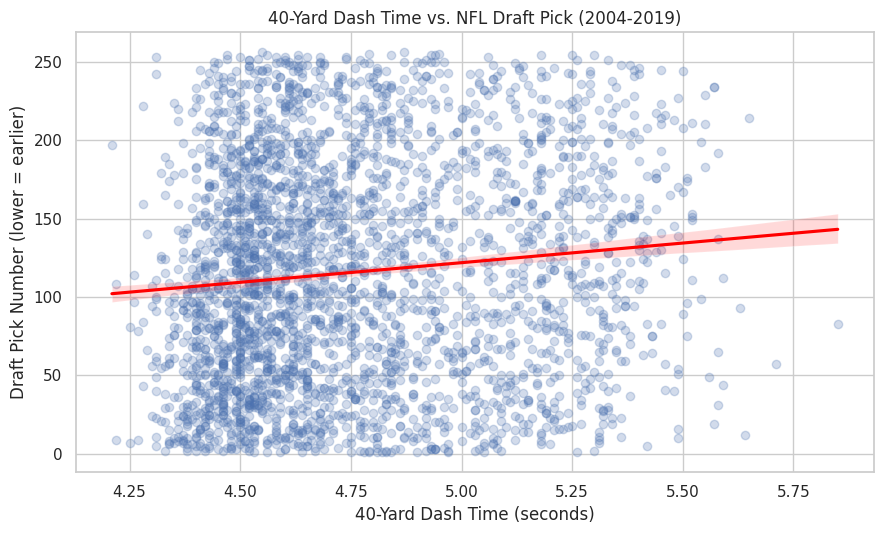

```python
corr_40yd = df["combine40yd"].corr(df["pick"])
print(f"Correlation between 40-yard dash time and draft pick: {corr_40yd:.3f}")

plt.figure(figsize=(9, 5.5))
sns.regplot(x="combine40yd", y="pick", data=df, scatter_kws={"alpha": 0.25}, line_kws={"color": "red"})
plt.title("40-Yard Dash Time vs. NFL Draft Pick (2004-2019)")
plt.xlabel("40-Yard Dash Time (seconds)")
plt.ylabel("Draft Pick Number (lower = earlier)")
plt.tight_layout()
plt.show()
```

### 3.3 Hypothesis test: WR vs. TE 40-yard dash times

**Claim:** Wide receivers run significantly faster 40-yard dash times than tight ends.

$H_0$: mean 40-yard dash time for WRs = mean 40-yard dash time for TEs. $H_1$: mean 40-yard dash time for WRs $\ne$ mean 40-yard dash time for TEs. We use Welch's t-test (unequal variances) at $\alpha = 0.05$.

```
WR mean 40yd: 4.484s (n=381)
TE mean 40yd: 4.728s (n=164)
T-statistic: -20.83, P-value: 0.000000
```

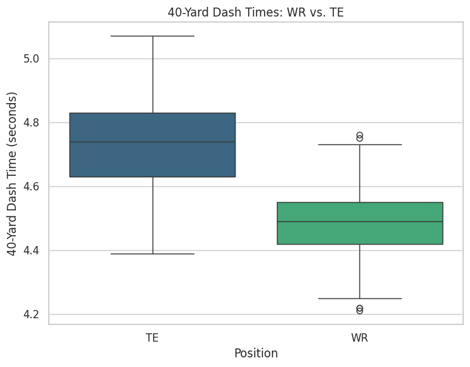

```python
wr_40 = df[(df["posGroup"] == "WR") & df["combine40yd"].notna()]["combine40yd"]
te_40 = df[(df["posGroup"] == "TE") & df["combine40yd"].notna()]["combine40yd"]

t_stat, p_value = stats.ttest_ind(wr_40, te_40, equal_var=False)
print(f"WR mean 40yd: {wr_40.mean():.3f}s (n={len(wr_40)})")
print(f"TE mean 40yd: {te_40.mean():.3f}s (n={len(te_40)})")
print(f"T-statistic: {t_stat:.2f}, P-value: {p_value:.6f}")

plt.figure(figsize=(7, 5.5))
sns.boxplot(x="posGroup", y="combine40yd",
            data=df[df["posGroup"].isin(["WR", "TE"])], hue="posGroup", legend=False, palette="viridis")
plt.title("40-Yard Dash Times: WR vs. TE")
plt.xlabel("Position")
plt.ylabel("40-Yard Dash Time (seconds)")
plt.tight_layout()
plt.show()
```

```python
if p_value < 0.05:
    print(f"p = {p_value:.6f} < 0.05: we reject H0. WRs and TEs have significantly different 40-yard dash times.")
else:
    print(f"p = {p_value:.6f} >= 0.05: we fail to reject H0.")
```

```
p = 0.000000 < 0.05: we reject H0. WRs and TEs have significantly different 40-yard dash times.
```

### 3.4 Which single combine metric correlates most with draft pick?

We compare 40-yard dash time against vertical jump (a proxy for explosiveness) as predictors of draft pick, to motivate which raw metrics are worth including in the ML model later.

```
corr(40yd, pick)  = 0.106
corr(vert, pick)  = -0.133
```

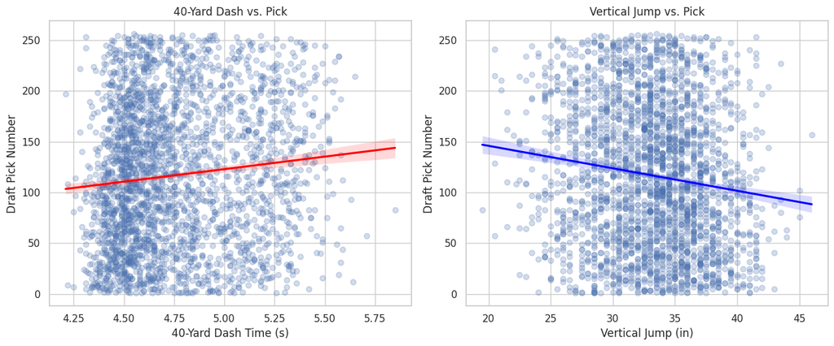

```python
df_pair = df[["combine40yd", "combineVert", "pick"]].dropna()

corr_40_pick = df_pair["combine40yd"].corr(df_pair["pick"])
corr_vert_pick = df_pair["combineVert"].corr(df_pair["pick"])
print(f"corr(40yd, pick)  = {corr_40_pick:.3f}")
print(f"corr(vert, pick)  = {corr_vert_pick:.3f}")

fig, axes = plt.subplots(1, 2, figsize=(13, 5.5))
sns.regplot(x="combine40yd", y="pick", data=df_pair, ax=axes[0],
            scatter_kws={"alpha": 0.25}, line_kws={"color": "red"})
axes[0].set_title("40-Yard Dash vs. Pick")
axes[0].set_xlabel("40-Yard Dash Time (s)")
axes[0].set_ylabel("Draft Pick Number")

sns.regplot(x="combineVert", y="pick", data=df_pair, ax=axes[1],
            scatter_kws={"alpha": 0.25}, line_kws={"color": "blue"})
axes[1].set_title("Vertical Jump vs. Pick")
axes[1].set_xlabel("Vertical Jump (in)")
axes[1].set_ylabel("Draft Pick Number")

plt.tight_layout()
plt.show()
```

**Takeaway from EDA:** both metrics have the expected sign, but neither is a strong predictor in isolation — correlation magnitudes are well below 0.5. That tells us a **single raw combine number is not enough**, but it doesn't rule out combine testing mattering once we account for *position* and combine *several* metrics together — which is exactly what our primary ML analysis investigates next.

## 4. Primary Analysis: Predicting Draft Pick with Machine Learning

### 4.1 Choice of technique

Our target, **draft pick number**, is a continuous variable (1 to ~256), so this is a **regression** problem (not classification). We picked regression over classification because predicting the exact pick (or the round, which is just `ceil(pick / 32)`) as a continuous score lets us measure *how* wrong the model is (a prediction of pick 5 for the actual 1st pick is a "close miss"; classification into discrete rounds would treat that the same as being off by 6 rounds).

We compare two models:

- **Linear Regression** — a simple, interpretable baseline. If a linear model already captures most of the signal, that supports "combine metrics have a roughly linear relationship with draft stock."
- **Random Forest Regressor** — a non-linear ensemble model that can capture interactions (e.g., "a fast 40 time matters a lot for WRs but barely for OL") without us having to hand-engineer those interactions. Its built-in feature importances also let us directly answer "which combine metric matters most?"

### 4.2 Features

We use the combine athletic testing numbers plus position group (one-hot encoded) as predictors. We exclude `combineArm`/`combine60ydShuttle`/`combineWonderlic` since they are missing for nearly every player in our filtered date range, and we impute the remaining missing combine numbers with the **median value for that player's position group** (a wide receiver's missing bench press is better estimated from other WRs than from the whole league).

```python
from sklearn.model_selection import train_test_split
from sklearn.linear_model import LinearRegression
from sklearn.ensemble import RandomForestRegressor
from sklearn.metrics import mean_absolute_error, mean_squared_error, r2_score
from sklearn.preprocessing import OneHotEncoder
from sklearn.compose import ColumnTransformer
from sklearn.pipeline import Pipeline

numeric_features = ["combine40yd", "combineVert", "combineBench",
                     "combineShuttle", "combineBroad", "combine3cone",
                     "combineWeight", "combineHeight"]
categorical_features = ["posGroup"]

model_df = df[numeric_features + categorical_features + ["pick"]].copy()

# Impute missing combine numbers with the median for that player's position group
for col in numeric_features:
    model_df[col] = model_df.groupby("posGroup")[col].transform(lambda s: s.fillna(s.median()))
    model_df[col] = model_df[col].fillna(model_df[col].median())  # safety net for any group with all-NaN

print("Missing values remaining:")
print(model_df.isna().sum())
```

```
Missing values remaining:
combine40yd       0
combineVert       0
combineBench      0
combineShuttle    0
combineBroad      0
combine3cone      0
combineWeight     0
combineHeight     0
posGroup          0
pick              0
dtype: int64
```

```python
X = model_df[numeric_features + categorical_features]
y = model_df["pick"]

X_train, X_test, y_train, y_test = train_test_split(X, y, test_size=0.2, random_state=42)

preprocessor = ColumnTransformer(transformers=[
    ("num", "passthrough", numeric_features),
    ("cat", OneHotEncoder(handle_unknown="ignore"), categorical_features),
])

print(f"Train size: {X_train.shape[0]}, Test size: {X_test.shape[0]}")
```

```
Train size: 2533, Test size: 634
```

### 4.3 Training and evaluating both models

We evaluate with three standard regression metrics:

- **MAE** (mean absolute error) — average number of picks the prediction is off by, in the same units as the target, so it's directly interpretable ("off by ~50 picks on average").
- **RMSE** (root mean squared error) — like MAE but penalizes large misses more.
- **R²** — fraction of variance in draft pick explained by the model (0 = no better than predicting the mean pick for everyone, 1 = perfect).

```python
results = {}

lin_pipe = Pipeline([("prep", preprocessor), ("model", LinearRegression())])
lin_pipe.fit(X_train, y_train)
lin_pred = lin_pipe.predict(X_test)
results["Linear Regression"] = {
    "MAE": mean_absolute_error(y_test, lin_pred),
    "RMSE": mean_squared_error(y_test, lin_pred) ** 0.5,
    "R2": r2_score(y_test, lin_pred),
}

rf_pipe = Pipeline([("prep", preprocessor),
                     ("model", RandomForestRegressor(n_estimators=300, max_depth=8,
                                                       random_state=42, n_jobs=-1))])
rf_pipe.fit(X_train, y_train)
rf_pred = rf_pipe.predict(X_test)
results["Random Forest"] = {
    "MAE": mean_absolute_error(y_test, rf_pred),
    "RMSE": mean_squared_error(y_test, rf_pred) ** 0.5,
    "R2": r2_score(y_test, rf_pred),
}

results_df = pd.DataFrame(results).T.round(2)
results_df
```

|  | MAE | RMSE | R2 |
| --- | --- | --- | --- |
| Linear Regression | 56.96 | 68.70 | 0.08 |
| Random Forest | 57.62 | 69.08 | 0.07 |

### 4.4 Feature importance

Using the Random Forest's built-in importances, we can see which features the model actually leans on to make its predictions.

```python
ohe = rf_pipe.named_steps["prep"].named_transformers_["cat"]
cat_names = list(ohe.get_feature_names_out(categorical_features))
all_feature_names = numeric_features + cat_names

importances = rf_pipe.named_steps["model"].feature_importances_
importance_df = pd.DataFrame({"feature": all_feature_names, "importance": importances})
importance_df = importance_df.sort_values("importance", ascending=False).reset_index(drop=True)
importance_df
```

|  | feature | importance |
| --- | --- | --- |
| 0 | combine40yd | 0.177434 |
| 1 | combineWeight | 0.148235 |
| 2 | combineHeight | 0.132403 |
| 3 | combineBroad | 0.124871 |
| 4 | combineBench | 0.113411 |
| 5 | combine3cone | 0.101168 |
| 6 | combineShuttle | 0.080833 |
| 7 | combineVert | 0.079999 |
| 8 | posGroup_QB | 0.009033 |
| 9 | posGroup_RB | 0.008203 |
| 10 | posGroup_WR | 0.006655 |
| 11 | posGroup_DL | 0.005761 |
| 12 | posGroup_DB | 0.003399 |
| 13 | posGroup_LB | 0.003376 |
| 14 | posGroup_TE | 0.002549 |
| 15 | posGroup_ST | 0.001813 |
| 16 | posGroup_OL | 0.000857 |

## 5. Visualization

### 5.1 Predicted vs. actual draft pick

Each point is one player in the held-out test set. The red dashed line is "perfect prediction" (y = x) — points close to that line are picks the model got approximately right.

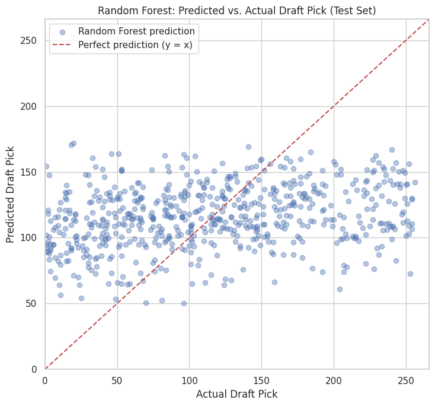

```python
plt.figure(figsize=(7.5, 7))
plt.scatter(y_test, rf_pred, alpha=0.4, label="Random Forest prediction")
lims = [0, max(y_test.max(), rf_pred.max()) + 10]
plt.plot(lims, lims, "r--", label="Perfect prediction (y = x)")
plt.xlabel("Actual Draft Pick")
plt.ylabel("Predicted Draft Pick")
plt.title("Random Forest: Predicted vs. Actual Draft Pick (Test Set)")
plt.legend()
plt.xlim(lims)
plt.ylim(lims)
plt.tight_layout()
plt.show()
```

### 5.2 Feature importance chart

This directly answers "which combine metric is the best predictor of draft position": bars further to the right contributed more to the Random Forest's predictions.

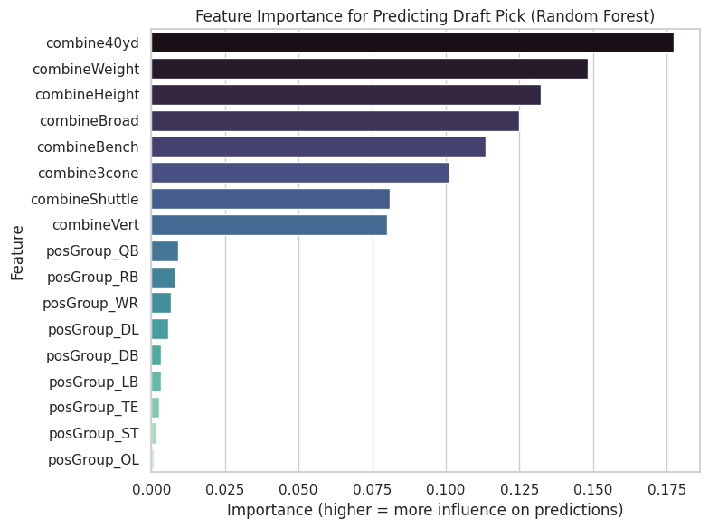

```python
plt.figure(figsize=(8, 6))
sns.barplot(data=importance_df, x="importance", y="feature", hue="feature",
            legend=False, palette="mako")
plt.title("Feature Importance for Predicting Draft Pick (Random Forest)")
plt.xlabel("Importance (higher = more influence on predictions)")
plt.ylabel("Feature")
plt.tight_layout()
plt.show()
```

### 5.3 Model error by position group

Is the model equally good at predicting picks for every position, or does it do better for some positions than others?

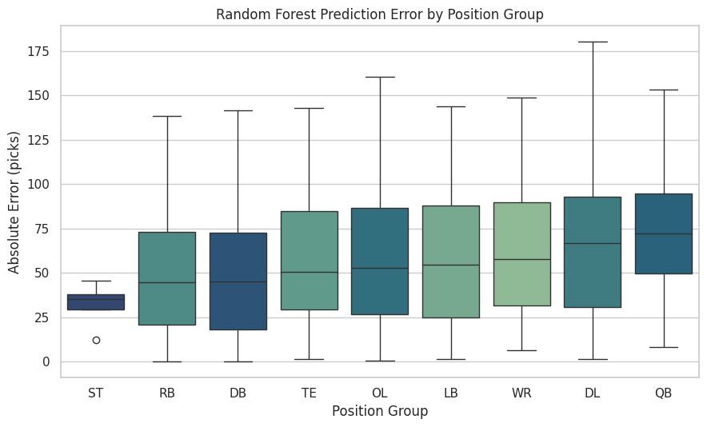

```python
error_df = X_test.copy()
error_df["actual_pick"] = y_test.values
error_df["predicted_pick"] = rf_pred
error_df["abs_error"] = (error_df["actual_pick"] - error_df["predicted_pick"]).abs()

plt.figure(figsize=(9, 5.5))
order = error_df.groupby("posGroup")["abs_error"].median().sort_values().index
sns.boxplot(data=error_df, x="posGroup", y="abs_error", order=order, hue="posGroup",
            legend=False, palette="crest")
plt.title("Random Forest Prediction Error by Position Group")
plt.xlabel("Position Group")
plt.ylabel("Absolute Error (picks)")
plt.tight_layout()
plt.show()
```

## 6. Insights and Conclusions

**On our original questions:**

**Would an uninformed reader come away informed?** Yes — the tutorial walks from raw combine/draft data through cleaning, targeted exploratory questions, and a full ML pipeline with a concrete, quantified takeaway about how much (or how little) combine testing predicts draft slot.

**Would an informed reader (e.g., someone who already follows the NFL Draft) learn something new?** The main non-obvious result is *how weak* the pure combine-to-draft-slot relationship is once you measure it directly (R² around 0.07–0.08) — media narratives around "he ran a 4.3, he's a first-rounder now" substantially overstate how much a single workout number moves draft stock in aggregate, even though the underlying correlations (Section 3) do point the expected direction. The per-position error analysis (Section 5.3) further shows which positions are hardest to predict from testing numbers alone — typically the ones (like QB) that NFL teams evaluate mostly on tape rather than athleticism.

**Limitations & future work:** we only use pre-draft testing numbers and position. Adding college production statistics (yards, sacks, completion percentage, etc., which exist elsewhere in this same Kaggle dataset) would likely explain substantially more variance, since film and production — not workout numbers — are what teams say they weigh most heavily. A model that also incorporates team-level draft need by year could further improve on the low R² we found here.

### Further reading

- [NFL Scouting Combine overview (NFL.com)](https://www.nfl.com/combine/) — background on what each drill measures.
- [scikit-learn: RandomForestRegressor documentation](https://scikit-learn.org/stable/modules/generated/sklearn.ensemble.RandomForestRegressor.html) — for readers who want to go deeper on how the ensemble model and its feature importances work.
- [SciPy: independent two-sample t-test documentation](https://docs.scipy.org/doc/scipy/reference/generated/scipy.stats.ttest_ind.html) — for readers who want the statistical background behind Section 3.3.